# Global Inflation Data Visualizations

.Mohammad - 100755461

The data set used for this assignment is the Global Inflation Data taken from Kaggle.com By examining this data, people can gain insights into the complex factors that impact the economy and make informed decisions about investments, policies.

The Figure 1 below represents the inflation across countries with IMF code starting with ‘1’. The horizontal bar chart shows inflation in year 2008. Each bar represents a country, and the length of the bar corresponds to its inflation rate during that year The bars are color-coded by the type of inflation with categorical breakdown: (Energy Consumer Price Inflation Food Consumer Price Inflation Headline Consumer Price Inflation Official Core Consumer Price Inflation Producer Price Inflation data) It allows us to see at a glance which countries had the highest and lowest inflation rates along with the division of categories and how they compare to each other. May be used to analyse a country’s economic growth as each type of inflation requires a different policy change/update.

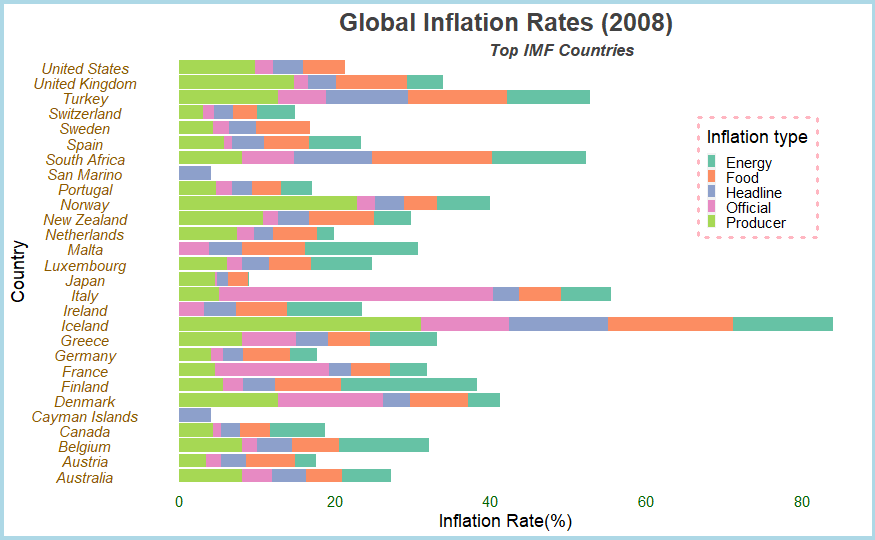

```
                                                        Figure 1
```

This is Figure 2 using same Global Inflation Dataset. I have used a choropleth map diagram to represent Food consumer Price inflation of countries with IMF code starting with ‘5’ in year 2020. The map uses color to represent the magnitude of the inflation rate, with darker shades of red indicating higher inflation rates and lighter shades indicating lower rates. The map also shows the outlines of the countries to help identify their locations. and highlights the regions where inflation rates were particularly high or low, which could be useful for identifying trends or patterns in inflation across regions or continents.

[figure not shown]

```
                                                      Figure 2
```

This diagram answers the question, “What is the inflation rate of the top International Monetary Fund (IMF) countries in 2021, and how does it relate to their GDP or GDP per Capita?” By plotting the inflation rate of different countries against their GDP, we can visualize any relationship or patterns between these two variables. The size of the bubble provides an additional dimension of information, allowing us to compare the countries’ GDP magnitudes. By using a gradient color scale, we can also distinguish between countries with high and low GDPs and see how they relate to the inflation rate.

This visualization can be useful for identifying any outliers, trends, or correlations in the data and understanding how different countries’ economic factors affect their inflation rates.

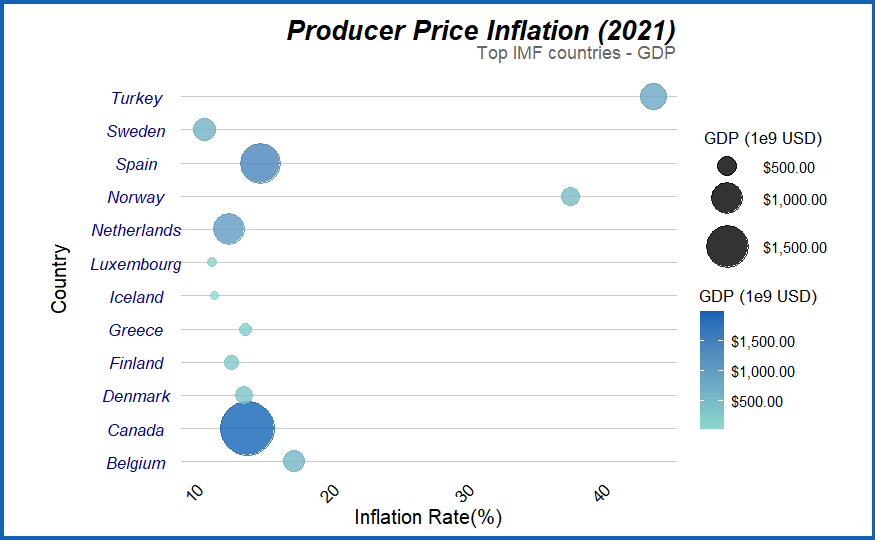

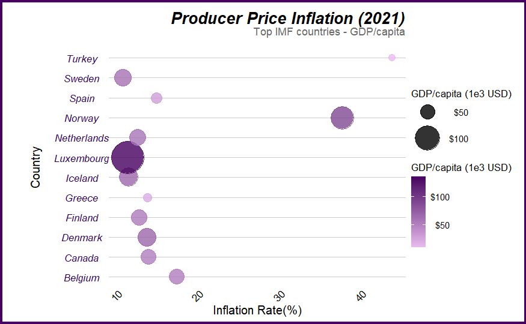

```
                                                          Figure 3 & 4
```

References: https://www.kaggle.com/datasets/belayethossainds/global-inflation-dataset-212-country-19702022 https://www.kaggle.com/datasets/tmishinev/world-country-gdp-19602021